# online_store_change

## intruduction :

The goals of the research:  
is to decide if a change that was made can have an effect of increasing conversion by 10% at all of the stages.  
From product_page → product_card → purchase .

- Presentation.
- Setup.
- Functions.
- step 1. Explore the data
- 1.1 Does it need converting types?
- Step 2. Prepare the data for analysis.
- 2.1 Rename the columns.
- 2.2 convert dates to datetime.
- 2.3 Add a date and time column
- 2.4 Are there any missing or duplicate values?
- 2.5 Check for duplicates.
- Step 3. Study and check the data.
- 3.1 Are there users who enter both samples?
- step 4. Carry out exploratory data analysis.
- 4.1 Study conversion at different funnel stages.
- 4.2 Is the number of events per user distributed equally
- 4.3 How is the number of events distributed by days?.
- 4.4 Think of the possible details
- step 5 Evaluate the A/B test results
- 5.1 What can you tell about the A/A test results
- 5.2 Use the z-criterion to check the statistical difference.
- 6 Describe the conclusions.

### Presentation.

Presentation: https://drive.google.com/file/d/1dFmsHsbb13pEPdZlgfhHHgrYJ2KsWNjv/view?usp=sharing

### Setup.

```python
import pandas as pd
import matplotlib.pyplot as plt
import seaborn as sns
from IPython.display import display
import datetime as dt
from datetime import datetime

import math
import numpy as np
from scipy import stats as st

from plotly import graph_objects as go

pd.options.display.max_columns = None

pd.options.display.max_colwidth = 200

pd.options.display.float_format = "{:,.2f}".format

from sklearn.model_selection import train_test_split
from sklearn.linear_model import LogisticRegression
from sklearn.preprocessing import StandardScaler
from sklearn.metrics import accuracy_score, precision_score, recall_score, f1_score
from sklearn.metrics import roc_auc_score
from sklearn.ensemble import RandomForestClassifier, GradientBoostingClassifier
from sklearn.ensemble import RandomForestRegressor
from scipy.cluster.hierarchy import dendrogram, linkage
from sklearn.cluster import KMeans
```

### Functions.

```python
def df_info(df):
    '''
    show information regarding the DF.
    '''

    display(df.head())
    print('shape:', df.shape)
    print()
    print('******** info() ********')
    print(df.info())
    print()
    print('******** info(memory_usage) ********')
    print(df.info(memory_usage = 'deep'))
    print()
    print('******** describe() ********')
    print(df.describe())
    print()
    print('******** describe(include) ********')
    print(df.describe(include = ['object']))
```

```python
def funnel(events_funnel):
    '''
    calculate the funnel stages of events.
    '''

    users = events_funnel.pivot_table(index = 'user_id', columns = 'event_name', values = 'event_dt', aggfunc = 'min')

    step_1 = ~users['login'].isna()
    step_2 = step_1 & (users['product_page'] >= users['login'])
    step_3 = step_2 & (users['product_cart'] >= users['product_page'])
    step_4 = step_3 & (users['purchase'] >= users['product_cart'])

    n_login = users[step_1].shape[0]
    n_product_page = users[step_2].shape[0]
    n_product_card = users[step_3].shape[0]
    n_purchase = users[step_4].shape[0]

    print('login:', n_login)
    print('product_page:', n_product_page)
    print('product_card:', n_product_card)
    print('purchase:', n_purchase)

    return (n_login, n_product_page, n_product_card, n_purchase)
```

```python
def go_funnel(n_login, n_product_page, n_product_card, n_purchase, title):
    fig = go.Figure(go.Funnel(
        x = [n_login, n_product_page, n_product_card, n_purchase],
        y = ['login', 'product_page', 'product_cart', 'purchase'],
        textposition = 'inside',
        textinfo = 'value+percent initial'))
    fig.update_layout(title = title)
    fig.show()
```

```python
def check_hypothesis(trials1, trials2, group1,group2, event, alpha=0.05):

    '''
    decide if the H0 can be rejected
    '''

    #how many users at each event
    successes1=pivot[pivot.event_name==event][group1].iloc[0]
    successes2=pivot[pivot.event_name==event][group2].iloc[0]

    #proportion for success in the first group
    p1 = successes1/trials1

   #proportion for success in the second group
    p2 = successes2/trials2

    # proportion in a combined dataset
    p_combined = (successes1 + successes2) / (trials1 + trials2)


    difference = p1 - p2


    z_value = difference / math.sqrt(p_combined * (1 - p_combined) * (1/trials1 + 1/trials2))


    distr = st.norm(0, 1)


    p_value = (1 - distr.cdf(abs(z_value))) * 2

    print()
    print('p-value: ', p_value)

    if (p_value < alpha):
        print("Reject H0 for",event, 'at groups',group1,group2)
    else:
        print("Fail to Reject H0 for", event,'at groups',group1,group2)
```

```python
def go_funnel_two(n_login_0, n_product_page_0, n_product_card_0, n_purchase_0,
                 n_login_1, n_product_page_1, n_product_card_1, n_purchase_1,
                 name0, name1, title):
    '''
    create two funnels togther
    '''

    fig = go.Figure()

    fig.add_trace(go.Funnel(
    name = name0,
    x = [n_login_0, n_product_page_0, n_product_card_0, n_purchase_0],
    y = ['login', 'product_page', 'product_cart', 'purchase'],
    textinfo = 'value+percent initial'
    ))

    fig.add_trace(go.Funnel(
    name = name1,
    x = [n_login_1, n_product_page_1, n_product_card_1, n_purchase_1],
    y = ['login', 'product_page', 'product_cart', 'purchase'],
    textinfo = 'value+percent initial'
    ))

    fig.update_layout(title = title)
    fig.show()
```

### step 1. Explore the data, Open the data file and read the general information

Download the data and prepare it for analysis

```python
marketing = pd.read_csv('ab_project_marketing_events_us.csv', sep=',')
events = pd.read_csv('final_ab_events_us.csv', sep=',')
new_users = pd.read_csv('final_ab_new_users_us.csv', sep=',')
participants = pd.read_csv('final_ab_participants_us.csv', sep=',')
```

### 1.1 Does it need converting types?

explore: marketing

```python
df_info(marketing)
```

|  | name | regions | start_dt | finish_dt |
| --- | --- | --- | --- | --- |
| 0 | Christmas&New Year Promo | EU, N.America | 2020-12-25 | 2021-01-03 |
| 1 | St. Valentine's Day Giveaway | EU, CIS, APAC, N.America | 2020-02-14 | 2020-02-16 |
| 2 | St. Patric's Day Promo | EU, N.America | 2020-03-17 | 2020-03-19 |
| 3 | Easter Promo | EU, CIS, APAC, N.America | 2020-04-12 | 2020-04-19 |
| 4 | 4th of July Promo | N.America | 2020-07-04 | 2020-07-11 |

```
shape: (14, 4)

******** info() ********
<class 'pandas.core.frame.DataFrame'>
RangeIndex: 14 entries, 0 to 13
Data columns (total 4 columns):
 #   Column     Non-Null Count  Dtype
---  ------     --------------  -----
 0   name       14 non-null     object
 1   regions    14 non-null     object
 2   start_dt   14 non-null     object
 3   finish_dt  14 non-null     object
dtypes: object(4)
memory usage: 576.0+ bytes
None

******** info(memory_usage) ********
<class 'pandas.core.frame.DataFrame'>
RangeIndex: 14 entries, 0 to 13
Data columns (total 4 columns):
 #   Column     Non-Null Count  Dtype
---  ------     --------------  -----
 0   name       14 non-null     object
 1   regions    14 non-null     object
 2   start_dt   14 non-null     object
 3   finish_dt  14 non-null     object
dtypes: object(4)
memory usage: 4.0 KB
None

******** describe() ********
                         name regions    start_dt   finish_dt
count                      14      14          14          14
unique                     14       6          14          14
top     Chinese Moon Festival    APAC  2020-05-09  2020-07-01
freq                        1       4           1           1

******** describe(include) ********
                         name regions    start_dt   finish_dt
count                      14      14          14          14
unique                     14       6          14          14
top     Chinese Moon Festival    APAC  2020-05-09  2020-07-01
freq                        1       4           1           1
```

Conclusion:  
Columns: start_dt, finish_dt. Should be date time.  
There are 14 rows.  
No missing data.

explore: events

```python
df_info(events)
```

|  | user_id | event_dt | event_name | details |
| --- | --- | --- | --- | --- |
| 0 | E1BDDCE0DAFA2679 | 2020-12-07 20:22:03 | purchase | 99.99 |
| 1 | 7B6452F081F49504 | 2020-12-07 09:22:53 | purchase | 9.99 |
| 2 | 9CD9F34546DF254C | 2020-12-07 12:59:29 | purchase | 4.99 |
| 3 | 96F27A054B191457 | 2020-12-07 04:02:40 | purchase | 4.99 |
| 4 | 1FD7660FDF94CA1F | 2020-12-07 10:15:09 | purchase | 4.99 |

```
shape: (440317, 4)

******** info() ********
<class 'pandas.core.frame.DataFrame'>
RangeIndex: 440317 entries, 0 to 440316
Data columns (total 4 columns):
 #   Column      Non-Null Count   Dtype
---  ------      --------------   -----
 0   user_id     440317 non-null  object
 1   event_dt    440317 non-null  object
 2   event_name  440317 non-null  object
 3   details     62740 non-null   float64
dtypes: float64(1), object(3)
memory usage: 13.4+ MB
None

******** info(memory_usage) ********
<class 'pandas.core.frame.DataFrame'>
RangeIndex: 440317 entries, 0 to 440316
Data columns (total 4 columns):
 #   Column      Non-Null Count   Dtype
---  ------      --------------   -----
 0   user_id     440317 non-null  object
 1   event_dt    440317 non-null  object
 2   event_name  440317 non-null  object
 3   details     62740 non-null   float64
dtypes: float64(1), object(3)
memory usage: 93.4 MB
None

******** describe() ********
        details
count 62,740.00
mean      23.88
std       72.18
min        4.99
25%        4.99
50%        4.99
75%        9.99
max      499.99

******** describe(include) ********
                 user_id             event_dt event_name
count             440317               440317     440317
unique             58703               267268          4
top     A3917F81482141F2  2020-12-14 18:54:55      login
freq                  36                   10     189552
```

Explore: new_users

```python
df_info(new_users)
```

|  | user_id | first_date | region | device |
| --- | --- | --- | --- | --- |
| 0 | D72A72121175D8BE | 2020-12-07 | EU | PC |
| 1 | F1C668619DFE6E65 | 2020-12-07 | N.America | Android |
| 2 | 2E1BF1D4C37EA01F | 2020-12-07 | EU | PC |
| 3 | 50734A22C0C63768 | 2020-12-07 | EU | iPhone |
| 4 | E1BDDCE0DAFA2679 | 2020-12-07 | N.America | iPhone |

```
shape: (61733, 4)

******** info() ********
<class 'pandas.core.frame.DataFrame'>
RangeIndex: 61733 entries, 0 to 61732
Data columns (total 4 columns):
 #   Column      Non-Null Count  Dtype
---  ------      --------------  -----
 0   user_id     61733 non-null  object
 1   first_date  61733 non-null  object
 2   region      61733 non-null  object
 3   device      61733 non-null  object
dtypes: object(4)
memory usage: 1.9+ MB
None

******** info(memory_usage) ********
<class 'pandas.core.frame.DataFrame'>
RangeIndex: 61733 entries, 0 to 61732
Data columns (total 4 columns):
 #   Column      Non-Null Count  Dtype
---  ------      --------------  -----
 0   user_id     61733 non-null  object
 1   first_date  61733 non-null  object
 2   region      61733 non-null  object
 3   device      61733 non-null  object
dtypes: object(4)
memory usage: 15.4 MB
None

******** describe() ********
                 user_id  first_date region   device
count              61733       61733  61733    61733
unique             61733          17      4        4
top     71F41BE5380C47DA  2020-12-21     EU  Android
freq                   1        6290  46270    27520

******** describe(include) ********
                 user_id  first_date region   device
count              61733       61733  61733    61733
unique             61733          17      4        4
top     71F41BE5380C47DA  2020-12-21     EU  Android
freq                   1        6290  46270    27520
```

Explore: participants

```python
df_info(participants)
```

|  | user_id | group | ab_test |
| --- | --- | --- | --- |
| 0 | D1ABA3E2887B6A73 | A | recommender_system_test |
| 1 | A7A3664BD6242119 | A | recommender_system_test |
| 2 | DABC14FDDFADD29E | A | recommender_system_test |
| 3 | 04988C5DF189632E | A | recommender_system_test |
| 4 | 482F14783456D21B | B | recommender_system_test |

```
shape: (18268, 3)

******** info() ********
<class 'pandas.core.frame.DataFrame'>
RangeIndex: 18268 entries, 0 to 18267
Data columns (total 3 columns):
 #   Column   Non-Null Count  Dtype
---  ------   --------------  -----
 0   user_id  18268 non-null  object
 1   group    18268 non-null  object
 2   ab_test  18268 non-null  object
dtypes: object(3)
memory usage: 428.3+ KB
None

******** info(memory_usage) ********
<class 'pandas.core.frame.DataFrame'>
RangeIndex: 18268 entries, 0 to 18267
Data columns (total 3 columns):
 #   Column   Non-Null Count  Dtype
---  ------   --------------  -----
 0   user_id  18268 non-null  object
 1   group    18268 non-null  object
 2   ab_test  18268 non-null  object
dtypes: object(3)
memory usage: 3.7 MB
None

******** describe() ********
                 user_id  group            ab_test
count              18268  18268              18268
unique             16666      2                  2
top     9A5549A4A85FCF06      A  interface_eu_test
freq                   2   9655              11567

******** describe(include) ********
                 user_id  group            ab_test
count              18268  18268              18268
unique             16666      2                  2
top     9A5549A4A85FCF06      A  interface_eu_test
freq                   2   9655              11567
```

### Step 2. Prepare the data for analysis.

### 2.1 Rename the columns.

no need to change names

### 2.2 convert dates to datetime.

```python
marketing['start_dt'] = pd.to_datetime(marketing['start_dt'], format = '%Y-%m-%d')
marketing['finish_dt'] = pd.to_datetime(marketing['finish_dt'], format = '%Y-%m-%d')
events['event_dt'] = pd.to_datetime(events['event_dt'] , format = '%Y-%m-%d %H:%M:%S')
new_users['first_date'] = pd.to_datetime(new_users['first_date'], format = '%Y-%m-%d')
```

### 2.3 Add a date and time column and a separate column for dates to events.

```python
events['event_date'] = events['event_dt'].dt.date
events['event_time'] = events['event_dt'].dt.time
```

### 2.4 Are there any missing or duplicate values? If so, what's their nature?

### 2.5 Check for duplicates.

```python
marketing.duplicated().sum()
```

```
0
```

```python
events.duplicated().sum()
```

```
0
```

```python
new_users.duplicated().sum()
```

```
0
```

```python
participants.duplicated().sum()
```

```
0
```

Conclusion:  
there are no duplicated rows

```python
events[events['event_name'] != 'purchase']['details'].unique()
```

```
array([nan])
```

Conclusion:  
There are missing values at events dataset, at the details column.  
The column type is float, so that information is actually the purchasing amount.

### Step 3. Study and check the data.

How many events are in the logs

```python
events.event_name.unique()
```

```
array(['purchase', 'product_cart', 'product_page', 'login'], dtype=object)
```

Conclusion: there is a forth event, but it is no part of the task.

how many test groups are there ?

```python
participants.group.unique()
```

```
array(['A', 'B'], dtype=object)
```

```python
participants.ab_test.unique()
```

```
array(['recommender_system_test', 'interface_eu_test'], dtype=object)
```

### 3.1 Are there users who enter both samples?

sort out users from the interface_eu_test

```python
participants = participants[participants['ab_test'] == 'interface_eu_test']
participants.head()
```

|  | user_id | group | ab_test |
| --- | --- | --- | --- |
| 6701 | D4E530F6595A05A3 | A | interface_eu_test |
| 6702 | 773ECB64E45DEBAB | A | interface_eu_test |
| 6703 | 6BCB0F33D3BAB8C2 | A | interface_eu_test |
| 6704 | AABA4219186465C9 | A | interface_eu_test |
| 6705 | 2BA8FA8754D1FE50 | B | interface_eu_test |

sort out the users from EU

```python
new_users['region'].unique()
```

```
array(['EU', 'N.America', 'APAC', 'CIS'], dtype=object)
```

```python
new_users_eu = new_users[new_users['region'] == 'EU']
new_users_eu.head()
```

|  | user_id | first_date | region | device |
| --- | --- | --- | --- | --- |
| 0 | D72A72121175D8BE | 2020-12-07 | EU | PC |
| 2 | 2E1BF1D4C37EA01F | 2020-12-07 | EU | PC |
| 3 | 50734A22C0C63768 | 2020-12-07 | EU | iPhone |
| 7 | 8942E64218C9A1ED | 2020-12-07 | EU | PC |
| 9 | FFCEA1179C253104 | 2020-12-07 | EU | Android |

list all the users from group A

```python
users_A = participants[participants['group'] == 'A']
users_A.head()
```

|  | user_id | group | ab_test |
| --- | --- | --- | --- |
| 6701 | D4E530F6595A05A3 | A | interface_eu_test |
| 6702 | 773ECB64E45DEBAB | A | interface_eu_test |
| 6703 | 6BCB0F33D3BAB8C2 | A | interface_eu_test |
| 6704 | AABA4219186465C9 | A | interface_eu_test |
| 6708 | 4BA448BCE1343C6F | A | interface_eu_test |

list all the users from group B

```python
users_B = participants[participants['group'] == 'B']
users_B.head()
```

|  | user_id | group | ab_test |
| --- | --- | --- | --- |
| 6705 | 2BA8FA8754D1FE50 | B | interface_eu_test |
| 6706 | FB6F6BC119E1DBD5 | B | interface_eu_test |
| 6707 | 2D2E7AA539CF348F | B | interface_eu_test |
| 6709 | 76B6CDF2A8B1DBFC | B | interface_eu_test |
| 6712 | 10DAD07E71B44F26 | B | interface_eu_test |

join the lists

```python
users_A_B = users_A.merge(users_B, how = 'inner', on = 'user_id')
users_A_B.head()
```

|  | user_id | group_x | ab_test_x | group_y | ab_test_y |
| --- | --- | --- | --- | --- | --- |

```python
#participants[participants['user_id'] == 'FC3F3E4DA7C85F88']
```

```python
users_A_B.shape
```

```
(0, 5)
```

```python
#users_both = users_A_B['user_id'].unique()
```

```python
#len(users_both)
```

```python
#participants.shape
```

```python
#participants = participants[~participants['user_id'].isin(users_both)]
```

```python
#participants.shape
```

### step 4. Carry out exploratory data analysis.

merge new_users_eu with participants

```python
new_users_eu = new_users_eu.merge(participants, on = 'user_id', how = 'left')
new_users_eu.head()
```

|  | user_id | first_date | region | device | group | ab_test |
| --- | --- | --- | --- | --- | --- | --- |
| 0 | D72A72121175D8BE | 2020-12-07 | EU | PC | NaN | NaN |
| 1 | 2E1BF1D4C37EA01F | 2020-12-07 | EU | PC | A | interface_eu_test |
| 2 | 50734A22C0C63768 | 2020-12-07 | EU | iPhone | B | interface_eu_test |
| 3 | 8942E64218C9A1ED | 2020-12-07 | EU | PC | NaN | NaN |
| 4 | FFCEA1179C253104 | 2020-12-07 | EU | Android | NaN | NaN |

```python
new_users_eu.shape
```

```
(46270, 6)
```

drop users that are not in any of the test groups

```python
new_users_eu = new_users_eu.dropna(subset = ['group'])
new_users_eu.head()
```

|  | user_id | first_date | region | device | group | ab_test |
| --- | --- | --- | --- | --- | --- | --- |
| 1 | 2E1BF1D4C37EA01F | 2020-12-07 | EU | PC | A | interface_eu_test |
| 2 | 50734A22C0C63768 | 2020-12-07 | EU | iPhone | B | interface_eu_test |
| 7 | E6DE857AFBDC6102 | 2020-12-07 | EU | PC | B | interface_eu_test |
| 8 | 5BE017E9C8CC42F8 | 2020-12-07 | EU | Android | B | interface_eu_test |
| 11 | 96F27A054B191457 | 2020-12-07 | EU | iPhone | B | interface_eu_test |

```python
new_users_eu.shape
```

```
(11567, 6)
```

merge new_users_eu with events

```python
events_eu = events.merge(new_users_eu, on = 'user_id', how = 'left')
events_eu.head()
```

|  | user_id | event_dt | event_name | details | event_date | event_time | first_date | region | device | group | ab_test |
| --- | --- | --- | --- | --- | --- | --- | --- | --- | --- | --- | --- |
| 0 | E1BDDCE0DAFA2679 | 2020-12-07 20:22:03 | purchase | 99.99 | 2020-12-07 | 20:22:03 | NaT | NaN | NaN | NaN | NaN |
| 1 | 7B6452F081F49504 | 2020-12-07 09:22:53 | purchase | 9.99 | 2020-12-07 | 09:22:53 | NaT | NaN | NaN | NaN | NaN |
| 2 | 9CD9F34546DF254C | 2020-12-07 12:59:29 | purchase | 4.99 | 2020-12-07 | 12:59:29 | NaT | NaN | NaN | NaN | NaN |
| 3 | 96F27A054B191457 | 2020-12-07 04:02:40 | purchase | 4.99 | 2020-12-07 | 04:02:40 | 2020-12-07 | EU | iPhone | B | interface_eu_test |
| 4 | 1FD7660FDF94CA1F | 2020-12-07 10:15:09 | purchase | 4.99 | 2020-12-07 | 10:15:09 | NaT | NaN | NaN | NaN | NaN |

drop users that are not in any of the test groups

```python
events_eu = events_eu.dropna(subset = ['group'])
events_eu.head()
```

|  | user_id | event_dt | event_name | details | event_date | event_time | first_date | region | device | group | ab_test |
| --- | --- | --- | --- | --- | --- | --- | --- | --- | --- | --- | --- |
| 3 | 96F27A054B191457 | 2020-12-07 04:02:40 | purchase | 4.99 | 2020-12-07 | 04:02:40 | 2020-12-07 | EU | iPhone | B | interface_eu_test |
| 9 | A92195E3CFB83DBD | 2020-12-07 00:32:07 | purchase | 4.99 | 2020-12-07 | 00:32:07 | 2020-12-07 | EU | Android | A | interface_eu_test |
| 11 | 354D653172FF2A2D | 2020-12-07 15:45:11 | purchase | 4.99 | 2020-12-07 | 15:45:11 | 2020-12-07 | EU | Mac | A | interface_eu_test |
| 12 | 7FCD34F47C13A9AC | 2020-12-07 22:06:13 | purchase | 9.99 | 2020-12-07 | 22:06:13 | 2020-12-07 | EU | PC | B | interface_eu_test |
| 13 | 0313C457F07C339E | 2020-12-07 13:10:48 | purchase | 9.99 | 2020-12-07 | 13:10:48 | 2020-12-07 | EU | Mac | A | interface_eu_test |

create two lists of users by groups

```python
events_eu_a = events_eu[events_eu['group'] == 'A']
events_eu_a.head()
```

|  | user_id | event_dt | event_name | details | event_date | event_time | first_date | region | device | group | ab_test |
| --- | --- | --- | --- | --- | --- | --- | --- | --- | --- | --- | --- |
| 9 | A92195E3CFB83DBD | 2020-12-07 00:32:07 | purchase | 4.99 | 2020-12-07 | 00:32:07 | 2020-12-07 | EU | Android | A | interface_eu_test |
| 11 | 354D653172FF2A2D | 2020-12-07 15:45:11 | purchase | 4.99 | 2020-12-07 | 15:45:11 | 2020-12-07 | EU | Mac | A | interface_eu_test |
| 13 | 0313C457F07C339E | 2020-12-07 13:10:48 | purchase | 9.99 | 2020-12-07 | 13:10:48 | 2020-12-07 | EU | Mac | A | interface_eu_test |
| 41 | F2BE35774F63059B | 2020-12-07 05:23:18 | purchase | 4.99 | 2020-12-07 | 05:23:18 | 2020-12-07 | EU | Android | A | interface_eu_test |
| 47 | 5C31C0607EFC3C98 | 2020-12-07 20:19:32 | purchase | 4.99 | 2020-12-07 | 20:19:32 | 2020-12-07 | EU | iPhone | A | interface_eu_test |

```python
events_eu_a.user_id.nunique()
```

```
5467
```

```python
events_eu_b = events_eu[events_eu['group'] == 'B']
events_eu_b.head()
```

|  | user_id | event_dt | event_name | details | event_date | event_time | first_date | region | device | group | ab_test |
| --- | --- | --- | --- | --- | --- | --- | --- | --- | --- | --- | --- |
| 3 | 96F27A054B191457 | 2020-12-07 04:02:40 | purchase | 4.99 | 2020-12-07 | 04:02:40 | 2020-12-07 | EU | iPhone | B | interface_eu_test |
| 12 | 7FCD34F47C13A9AC | 2020-12-07 22:06:13 | purchase | 9.99 | 2020-12-07 | 22:06:13 | 2020-12-07 | EU | PC | B | interface_eu_test |
| 25 | C39E95E709714A06 | 2020-12-07 09:07:20 | purchase | 4.99 | 2020-12-07 | 09:07:20 | 2020-12-07 | EU | Android | B | interface_eu_test |
| 30 | 78B3AFBB700310CC | 2020-12-07 23:44:09 | purchase | 4.99 | 2020-12-07 | 23:44:09 | 2020-12-07 | EU | PC | B | interface_eu_test |
| 31 | 80CEAF824A1F3E28 | 2020-12-07 15:54:06 | purchase | 499.99 | 2020-12-07 | 15:54:06 | 2020-12-07 | EU | Android | B | interface_eu_test |

```python
events_eu_b.user_id.nunique()
```

```
5383
```

conclosions:  
there are 5467 users at group A.  
there are 5383 users at group B.

```python
events_eu['event_dt'].min()
```

```
Timestamp('2020-12-07 00:02:48')
```

```python
events_eu['event_dt'].max()
```

```
Timestamp('2020-12-30 18:28:55')
```

### 4.1 Study conversion at different funnel stages.

For each user, find the time of the first occurrence of each event.

```python
users_a = events_eu_a.pivot_table(index = 'user_id', columns = 'event_name', values = 'event_dt', aggfunc = 'min')
users_a.head()
```

| event_name user_id | login | product_cart | product_page | purchase |
| --- | --- | --- | --- | --- |
| 0002CE61FF2C4011 | 2020-12-07 04:37:36 | 2020-12-07 04:37:37 | 2020-12-07 04:37:42 | NaT |
| 002412F1EB3F6E38 | 2020-12-09 09:35:20 | NaT | 2020-12-09 09:35:20 | NaT |
| 002540BE89C930FB | 2020-12-08 18:05:24 | 2020-12-08 18:05:24 | 2020-12-08 18:05:24 | NaT |
| 003346BB64227D0C | 2020-12-17 05:24:01 | NaT | NaT | NaT |
| 00341D8401F0F665 | 2020-12-21 11:14:50 | NaT | NaT | NaT |

Let's find how many users proceeded from stage to stage.

the order of the stages: login → product_page → product_cart → purchase

funnel for group A

```python
n_login_a, n_product_page_a, n_product_card_a, n_purchase_a = funnel(events_eu_a)
```

```
login: 5466
product_page: 3639
product_card: 830
purchase: 113
```

Funnel Chart group A

```python
go_funnel(n_login_a, n_product_page_a, n_product_card_a, n_purchase_a, 'Funnel Chart group A')
```

[interactive chart not shown]

funnel for group B

```python
n_login_b, n_product_page_b, n_product_card_b, n_purchase_b = funnel(events_eu_b)
```

```
login: 5383
product_page: 3527
product_card: 850
purchase: 98
```

```python
go_funnel(n_login_b, n_product_page_b, n_product_card_b, n_purchase_b, 'Funnel Chart group B')
```

[interactive chart not shown]

```python
go_funnel_two(n_login_a, n_product_page_a, n_product_card_a, n_purchase_a,\
              n_login_b, n_product_page_b, n_product_card_b, n_purchase_b,\
              'A', 'B', 'Funnel of both groups')
```

[interactive chart not shown]

Conclusion:  
The expected result was a 10% increase in all stages of the funnel, and especially at conversion.  
Except for a mild increase at the product_cart event, there is actually a decrease in the percentage of all events.

### 4.2 Is the number of events per user distributed equally in the samples?

how many events does each user have ?

```python
users_events = events_eu.pivot_table(index = 'user_id', values = 'ab_test', columns = 'group', aggfunc = 'count')\
.reset_index()
users_events.head()
```

| group | user_id | A | B |
| --- | --- | --- | --- |
| 0 | 0002CE61FF2C4011 | 12.00 | nan |
| 1 | 001064FEAAB631A1 | nan | 6.00 |
| 2 | 001E72F50D1C48FA | nan | 6.00 |
| 3 | 002412F1EB3F6E38 | 8.00 | nan |
| 4 | 002540BE89C930FB | 9.00 | nan |

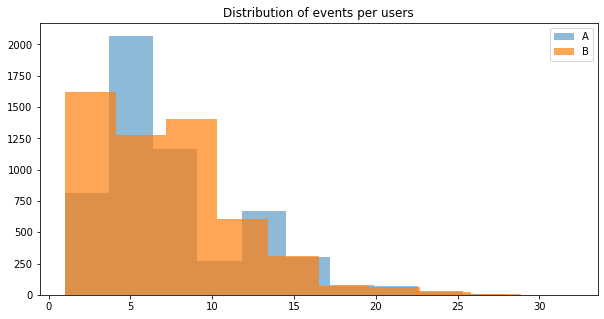

```python
plt.figure(figsize = (10, 5))
plt.hist(users_events['A'], label = 'A', alpha = 0.5)
plt.hist(users_events['B'], label = 'B', alpha = 0.7)
plt.legend(loc = 'best')
plt.title('Distribution of events per users')

plt.show()
```

Conclusion:

The Distribution of events per users looks similar.

### 4.3 How is the number of events distributed by days?

```python
events_days = events_eu.pivot_table(index = 'event_name', values = 'region', columns = 'event_date', aggfunc = 'count')
events_days.head()
```

| event_date event_name | 2020-12-07 | 2020-12-08 | 2020-12-09 | 2020-12-10 | 2020-12-11 | 2020-12-12 | 2020-12-13 | 2020-12-14 | 2020-12-15 | 2020-12-16 | 2020-12-17 | 2020-12-18 | 2020-12-19 | 2020-12-20 | 2020-12-21 | 2020-12-22 | 2020-12-23 | 2020-12-24 | 2020-12-25 | 2020-12-26 | 2020-12-27 | 2020-12-28 | 2020-12-29 | 2020-12-30 |
| --- | --- | --- | --- | --- | --- | --- | --- | --- | --- | --- | --- | --- | --- | --- | --- | --- | --- | --- | --- | --- | --- | --- | --- | --- |
| login | 903 | 996 | 1002 | 1076 | 1114 | 1486 | 1690 | 2068 | 1875 | 1716 | 1774 | 1838 | 1865 | 2076 | 2586 | 2298 | 2097 | 1592 | 1277 | 1126 | 1016 | 908 | 760 | 6 |
| product_cart | 270 | 310 | 343 | 366 | 361 | 528 | 571 | 664 | 614 | 566 | 574 | 600 | 633 | 679 | 875 | 735 | 681 | 521 | 444 | 364 | 355 | 298 | 247 | 3 |
| product_page | 586 | 665 | 651 | 731 | 752 | 971 | 1121 | 1326 | 1223 | 1117 | 1160 | 1177 | 1230 | 1344 | 1716 | 1531 | 1383 | 1051 | 836 | 750 | 671 | 604 | 495 | 4 |
| purchase | 309 | 340 | 337 | 378 | 376 | 497 | 592 | 725 | 621 | 617 | 607 | 604 | 632 | 729 | 893 | 788 | 746 | 526 | 441 | 393 | 354 | 306 | 271 | 3 |

```python
events_days.loc['total'] = events_days.select_dtypes(pd.np.number).sum()
events_days = events_days.drop(['login', 'product_cart', 'product_page', 'purchase'])
events_days
```

| event_date event_name | 2020-12-07 | 2020-12-08 | 2020-12-09 | 2020-12-10 | 2020-12-11 | 2020-12-12 | 2020-12-13 | 2020-12-14 | 2020-12-15 | 2020-12-16 | 2020-12-17 | 2020-12-18 | 2020-12-19 | 2020-12-20 | 2020-12-21 | 2020-12-22 | 2020-12-23 | 2020-12-24 | 2020-12-25 | 2020-12-26 | 2020-12-27 | 2020-12-28 | 2020-12-29 | 2020-12-30 |
| --- | --- | --- | --- | --- | --- | --- | --- | --- | --- | --- | --- | --- | --- | --- | --- | --- | --- | --- | --- | --- | --- | --- | --- | --- |
| total | 2068 | 2311 | 2333 | 2551 | 2603 | 3482 | 3974 | 4783 | 4333 | 4016 | 4115 | 4219 | 4360 | 4828 | 6070 | 5352 | 4907 | 3690 | 2998 | 2633 | 2396 | 2116 | 1773 | 16 |

```python
events_days = events_days.T.reset_index()
```

```python
fig = go.Figure()
# Add traces
fig.add_trace(go.Scatter(x=events_days['event_date'], y=events_days['total'],
                    mode='markers',
                    name='markers'))
fig.update_layout(title = 'Distributed of events by days')
fig.show()
```

[interactive chart not shown]

Conclusion:  
There is an increase in amount of events starting from the 12 of dec, there are spikes in activity on the 14 and 21 .  
I was looking into marketing activity near those dayrs at the EU, but there are non.

### 4.4 Think of the possible details in the data that you have to take into account before starting the A/B test?

Some possible details that need to be taken into account, but since the data is limited, we can not go into them.  
How was the population divided, regarding gender, age, background, education, income…

### step 5. Evaluate the A/B test results

### 5.1 What can you tell about the A/A test results

A/A tests was not conducted.

### 5.2 Use the z-criterion to check the statistical difference between the proportions

For calculating proportions we need to know the number of users in the group.

```python
test_1 = events_eu[events_eu.group == 'A']['user_id'].nunique()
test_1
```

```
5467
```

```python
test_2 = events_eu[events_eu.group == 'B']['user_id'].nunique()
test_2
```

```
5383
```

Now we have lists with our users from each group and we can use it in calculation of our proportions

```python
pivot = events_eu.pivot_table(index = 'event_name', values = 'user_id', \
                              columns = 'group', aggfunc = lambda x: x.nunique()).reset_index()
pivot
```

| group | event_name | A | B |
| --- | --- | --- | --- |
| 0 | login | 5466 | 5383 |
| 1 | product_cart | 1756 | 1812 |
| 2 | product_page | 3639 | 3527 |
| 3 | purchase | 1931 | 1782 |

The H0 hypothesis will be that the proportion of the events between the groups is the same.  
The H1 hypothesis will be that the proportions are different.

```python
for event_name in pivot.event_name.unique():
    check_hypothesis(test_1, test_2, 'A', 'B', event_name, alpha=0.05)
```

```
p-value:  0.32103485047255065
Fail to Reject H0 for login at groups A B

p-value:  0.08746918913258162
Fail to Reject H0 for product_cart at groups A B

p-value:  0.2518419682737163
Fail to Reject H0 for product_page at groups A B

p-value:  0.014959088807690257
Reject H0 for purchase at groups A B
```

Conclusion:  
The H0 hypothesis failed to reject for: login , product_cart , product_page events.  
It did reject the hypothesis regarding the proportion of the purchase Event.

Since the porpoise of the experiment was to increase conversion by 10% makes sense to continue checking the results.

### 6 Describe the conclusions on the EDA stage, as well as on the evaluation of the A/B test results

Conclusion:

The experiment weather the change will increase the conversion of all events by 10% has failed,  
as can clearly be seen at the funnels.  
Regarding the A/B test,  
besides a small lack of proportion at the purchase event, the rest of the events were proportional between the groups. So the groups were divided in a proportional way.